# Project Business Statistics: E-news Express

## Define Problem Statement and Objectives

## Business Context

The advent of e-news, or electronic news, portals has offered us a great opportunity to quickly get updates on the day-to-day events occurring globally. The information on these portals is retrieved electronically from online databases, processed using a variety of software, and then transmitted to the users. There are multiple advantages of transmitting new electronically, like faster access to the content and the ability to utilize different technologies such as audio, graphics, video, and other interactive elements that are either not being used or aren’t common yet in traditional newspapers.

E-news Express, an online news portal, aims to expand its business by acquiring new subscribers. With every visitor to the website taking certain actions based on their interest, the company plans to analyze these actions to understand user interests and determine how to drive better engagement. The executives at E-news Express are of the opinion that there has been a decline in new monthly subscribers compared to the past year because the current webpage is not designed well enough in terms of the outline & recommended content to keep customers engaged long enough to make a decision to subscribe.

[Companies often analyze user responses to two variants of a product to decide which of the two variants is more effective. This experimental technique, known as A/B testing, is used to determine whether a new feature attracts users based on a chosen metric.]

## Objective

The design team of the company has researched and created a new landing page that has a new outline & more relevant content shown compared to the old page. In order to test the effectiveness of the new landing page in gathering new subscribers, the Data Science team conducted an experiment by randomly selecting 100 users and dividing them equally into two groups. The existing landing page was served to the first group (control group) and the new landing page to the second group (treatment group). Data regarding the interaction of users in both groups with the two versions of the landing page was collected. Being a data scientist in E-news Express, you have been asked to explore the data and perform a statistical analysis (at a significance level of 5%) to determine the effectiveness of the new landing page in gathering new subscribers for the news portal by answering the following questions:

1. Do the users spend more time on the new landing page than on the existing landing page?
2. Is the conversion rate (the proportion of users who visit the landing page and get converted) for the new page greater than the conversion rate for the old page?
3. Does the converted status depend on the preferred language? [Hint: Create a contingency table using the pandas.crosstab() function]
4. Is the time spent on the new page the same for the different language users?

## Data Dictionary

The data contains information regarding the interaction of users in both groups with the two versions of the landing page.

1. user_id - Unique user ID of the person visiting the website
2. group - Whether the user belongs to the first group (control) or the second group (treatment)
3. landing_page - Whether the landing page is new or old
4. time_spent_on_the_page - Time (in minutes) spent by the user on the landing page
5. converted - Whether the user gets converted to a subscriber of the news portal or not
6. language_preferred - Language chosen by the user to view the landing page

## Import all the necessary libraries

```python
# Installing the libraries with the specified version.
!pip install numpy==1.25.2 pandas==1.5.3 matplotlib==3.7.1 seaborn==0.13.1 scipy==1.11.4 -q --user
```

**Note**: *After running the above cell, kindly restart the notebook kernel and run all cells sequentially from the start again.*

```python
# Libraries to help with reading and manipulating data
import numpy as np
import pandas as pd

# Libraries to help with data visualization
import matplotlib.pyplot as plt
import seaborn as sns
%matplotlib inline

# Library to help with statistical analysis
import scipy.stats as stats
```

## Reading the Data into a DataFrame

```python
#import google.colab
from google.colab import drive
drive.mount('/content/drive')
```

```python
# load the dataset
df = pd.read_csv('/content/drive/MyDrive/Python Course/abtest.csv')
```

## Explore the dataset and extract insights using Exploratory Data Analysis

- Data Overview
  - Viewing the first and last few rows of the dataset
  - Checking the shape of the dataset
  - Getting the statistical summary for the variables
- Check for missing values
- Check for duplicates

### Data Overview

#### Displaying the first few rows of the dataset

```python
# View the first few 5 rows of the dataset
df.head()
```

|  | user_id | group | landing_page | time_spent_on_the_page | converted | language_preferred |
| --- | --- | --- | --- | --- | --- | --- |
| 0 | 546592 | control | old | 3.48 | no | Spanish |
| 1 | 546468 | treatment | new | 7.13 | yes | English |
| 2 | 546462 | treatment | new | 4.40 | no | Spanish |
| 3 | 546567 | control | old | 3.02 | no | French |
| 4 | 546459 | treatment | new | 4.75 | yes | Spanish |

- The dataset contains the user_id, group, landing_page, time_spent_on_the_page, converted, and language_preferred for one user in each row.

#### Displaying the last few rows of the dataset

```python
# View the last 5 rows of the dataset
df.tail()
```

|  | user_id | group | landing_page | time_spent_on_the_page | converted | language_preferred |
| --- | --- | --- | --- | --- | --- | --- |
| 95 | 546446 | treatment | new | 5.15 | no | Spanish |
| 96 | 546544 | control | old | 6.52 | yes | English |
| 97 | 546472 | treatment | new | 7.07 | yes | Spanish |
| 98 | 546481 | treatment | new | 6.20 | yes | Spanish |
| 99 | 546483 | treatment | new | 5.86 | yes | English |

- The dataset has a total of 100 rows.

#### Checking the data types of the columns for the dataset

```python
# check the data types of the columns in the dataset
df.info()
```

```
<class 'pandas.core.frame.DataFrame'>
RangeIndex: 100 entries, 0 to 99
Data columns (total 6 columns):
 #   Column                  Non-Null Count  Dtype
---  ------                  --------------  -----
 0   user_id                 100 non-null    int64
 1   group                   100 non-null    object
 2   landing_page            100 non-null    object
 3   time_spent_on_the_page  100 non-null    float64
 4   converted               100 non-null    object
 5   language_preferred      100 non-null    object
dtypes: float64(1), int64(1), object(4)
memory usage: 4.8+ KB
```

#### Checking the shape of the dataset

```python
# check the shape of the dataset
df.shape
```

```
(100, 6)
```

- The dataset has 100 rows and 6 columns.

#### Getting the statistical summary for the numerical variables

```python
# check the numerical summary statistics for new and old

df.describe()
```

|  | user_id | time_spent_on_the_page |
| --- | --- | --- |
| count | 100.000000 | 100.000000 |
| mean | 546517.000000 | 5.377800 |
| std | 52.295779 | 2.378166 |
| min | 546443.000000 | 0.190000 |
| 25% | 546467.750000 | 3.880000 |
| 50% | 546492.500000 | 5.415000 |
| 75% | 546567.250000 | 7.022500 |
| max | 546592.000000 | 10.710000 |

- The average time spent on the page is 5.377800.
- The minimum time spent on the page is 0.19 and the maximum is 10.71.

#### Getting the statistical summary for the categorical variables

```python
# Check the statistical summary for the numerical variables
df.describe(include='object')
```

|  | group | landing_page | converted | language_preferred |
| --- | --- | --- | --- | --- |
| count | 100 | 100 | 100 | 100 |
| unique | 2 | 2 | 2 | 3 |
| top | control | old | yes | Spanish |
| freq | 50 | 50 | 54 | 34 |

- Count for the variables group, landing page converted, and language preferred as 100 each
- The variables group, landing page converted, and language preferred has unique values 2, 2, 2, and 3 respectively
- The most frequent value across the variables are control, old, yes, and spanish.

### Check for missing values

```python
df.isnull().sum()
```

|  | 0 |
| --- | --- |
| user_id | 0 |
| group | 0 |
| landing_page | 0 |
| time_spent_on_the_page | 0 |
| converted | 0 |
| language_preferred | 0 |

**dtype:** int64

- There are no missing values

### Check for duplicates

```python
df.duplicated().sum()
```

```
np.int64(0)
```

- There are no duplicates

### Univariate Analysis

#### Time spent on the page

```python
# Get descriptive statistics for 'time_spent_on_the_page'
print("Descriptive Statistics for Time Spent on the Page:")
print(df['time_spent_on_the_page'].describe())
```

```
Descriptive Statistics for Time Spent on the Page:
count    100.000000
mean       5.377800
std        2.378166
min        0.190000
25%        3.880000
50%        5.415000
75%        7.022500
max       10.710000
Name: time_spent_on_the_page, dtype: float64
```

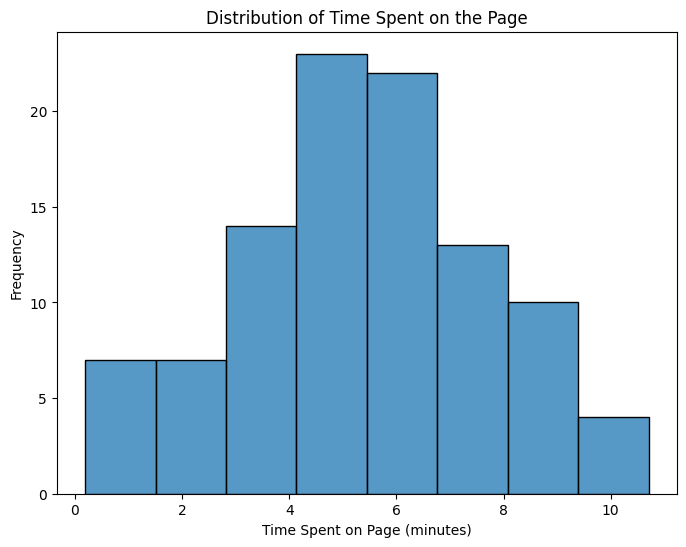

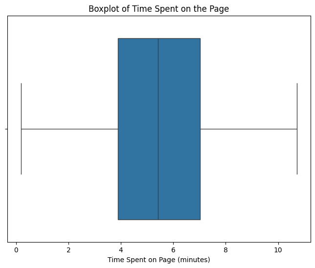

```python
# Check the distribution visually using a histogram
plt.figure(figsize=(8, 6))
sns.histplot(data=df, x='time_spent_on_the_page')
plt.title('Distribution of Time Spent on the Page')
plt.xlabel('Time Spent on Page (minutes)')
plt.ylabel('Frequency')
plt.show()

# Check for outliers using a boxplot
plt.figure(figsize=(8, 6))
sns.boxplot(data=df, x='time_spent_on_the_page')
plt.title('Boxplot of Time Spent on the Page')
plt.xlabel('Time Spent on Page (minutes)')
plt.show()
```

**Boxplot:** In this boxplot, there do not appear to be any significant outliers identified by the standard outlier detection method. The whiskers extend to the minimum and maximum values.

The variable 'time_spent_on_the_page' is a continuous numerical variable. The distribution appears somewhat symmetrical, centered around 5-6 minutes, with no extreme outliers. The majority of users spend between approximately 3.5 and 7 minutes on the page.

#### Group

```python
# Frequency distribution for 'group'
print("Frequency distribution for 'group':")
print(df['group'].value_counts())
```

```
Frequency distribution for 'group':
group
control      50
treatment    50
Name: count, dtype: int64
```

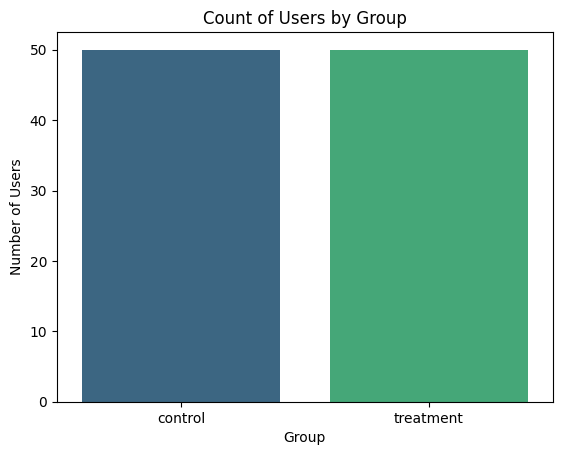

```python
# Count plot for 'group'
sns.countplot(data=df, x='group', hue='group', palette='viridis', legend=False)
plt.title('Count of Users by Group')
plt.xlabel('Group')
plt.ylabel('Number of Users')
plt.show()
```

- **Frequency Distribution:** The output shows that there are 50 users in the 'control' group and 50 users in the 'treatment' group.
- **Count Plot:** The bar chart visually confirms the counts, showing two bars of equal height for 'control' and 'treatment'.

#### Landing page

```python
# Frequency distribution for 'landing_page'
print("\nFrequency distribution for 'landing_page':")
print(df['landing_page'].value_counts())
```

```
Frequency distribution for 'landing_page':
landing_page
old    50
new    50
Name: count, dtype: int64
```

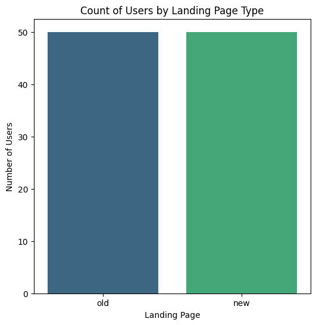

```python
# Count plot for 'landing_page'
plt.figure(figsize=(6, 6))
# Updated to avoid FutureWarning as done for 'group'
sns.countplot(data=df, x='landing_page', hue='landing_page', palette='viridis', legend=False)
plt.title('Count of Users by Landing Page Type')
plt.xlabel('Landing Page')
plt.ylabel('Number of Users')
plt.show()
```

- **Frequency Distribution:** The output shows 50 users saw the 'new' landing page and 50 users saw the 'old' landing page.
- **Count Plot:** The bar chart visually confirms these counts, showing equal numbers of users for each landing page type.

#### Converted

```python
# Frequency distribution for 'converted'
print("\nFrequency distribution for 'converted':")
print(df['converted'].value_counts())
```

```
Frequency distribution for 'converted':
converted
yes    54
no     46
Name: count, dtype: int64
```

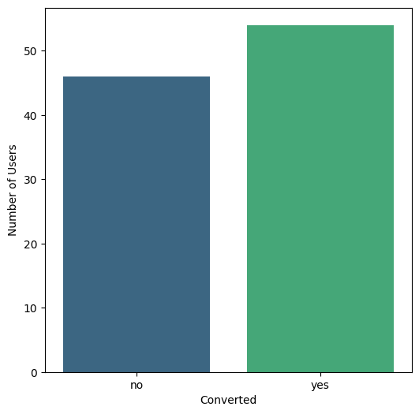

```python
# Count plot for 'converted'
plt.figure(figsize=(6, 6))
sns.countplot(data=df, x='converted', hue='converted', palette='viridis', legend=False)
plt.xlabel('Converted')
plt.ylabel('Number of Users')
plt.show()
```

#### Language preferred

```python
# Frequency distribution for 'language_preferred'
print("\nFrequency distribution for 'language_preferred':")
print(df['language_preferred'].value_counts())
```

```
Frequency distribution for 'language_preferred':
language_preferred
Spanish    34
French     34
English    32
Name: count, dtype: int64
```

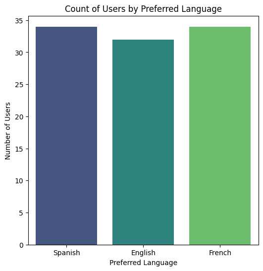

```python
# Count plot for 'language_preferred'
plt.figure(figsize=(6, 6))
sns.countplot(data=df, x='language_preferred', hue='language_preferred', palette='viridis', legend=False)
plt.title('Count of Users by Preferred Language')
plt.xlabel('Preferred Language')
plt.ylabel('Number of Users')
plt.show()
```

- **Frequency Distribution:** The output shows the count of users for each preferred language: English (32), French (34), and Spanish (34).
- **Count Plot:** The bar chart visually represents these counts, showing very similar numbers of users across the three language categories.

### Bivariate Analysis

#### Landing page vs Time spent on the page

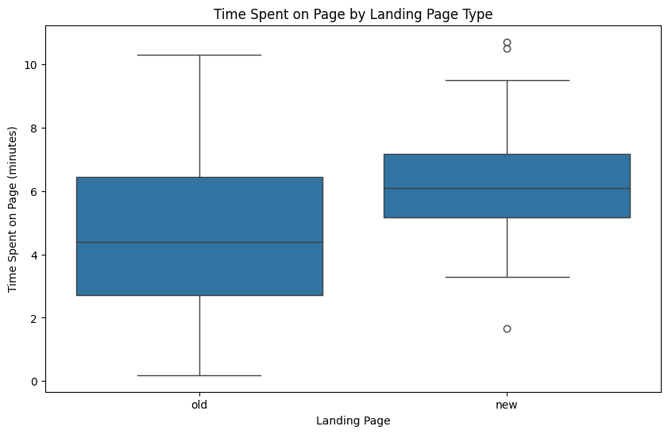

```python
plt.figure(figsize=(10, 6))
sns.boxplot(data=df, x='landing_page', y='time_spent_on_the_page')
plt.title('Time Spent on Page by Landing Page Type')
plt.xlabel('Landing Page')
plt.ylabel('Time Spent on Page (minutes)')
plt.show()
```

- The visual analysis suggests that users, on average, might be spending more time on the new landing page than on the old one.
- Visually comparing the medians and means, the 'new' landing page appears to have a higher central tendency for time spent compared to the 'old' landing page.

#### Conversion status vs Time spent on the page

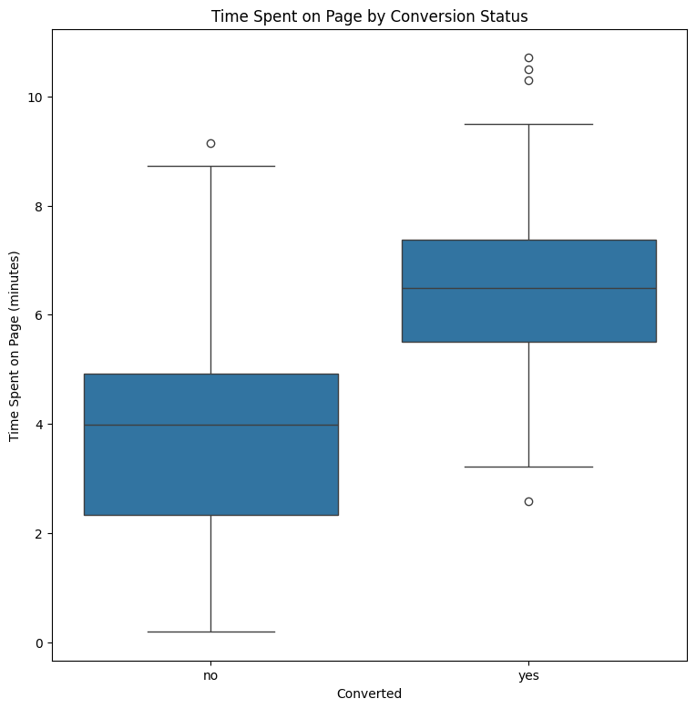

```python
plt.figure(figsize=(9, 9))
sns.boxplot(data = df, x = 'converted', y = 'time_spent_on_the_page')
plt.title('Time Spent on Page by Conversion Status')
plt.xlabel('Converted')
plt.ylabel('Time Spent on Page (minutes)')
plt.show()
```

- The box plot visually suggests that users who converted to subscribers tend to spend more time on the page than users who did not convert. The box and median for 'yes' appear higher than for 'no'.

#### Language preferred vs Time spent on the page

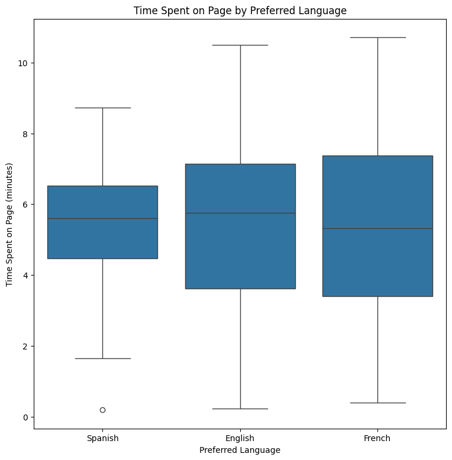

```python
plt.figure(figsize=(9, 9))
sns.boxplot(data = df, x = 'language_preferred', y = 'time_spent_on_the_page')
plt.title('Time Spent on Page by Preferred Language')
plt.xlabel('Preferred Language')
plt.ylabel('Time Spent on Page (minutes)')
plt.show()
```

- The box plot displays three boxes, one for each preferred language.
- Compare the central tendency (median and mean) and spread (interquartile range) across the three language groups.
- Visually, there seem to be some differences in the distribution of time spent across the language groups. For example, the median and box for Spanish look slightly different from English or French.

## 1. Do the users spend more time on the new landing page than the existing landing page?

### Perform Visual Analysis

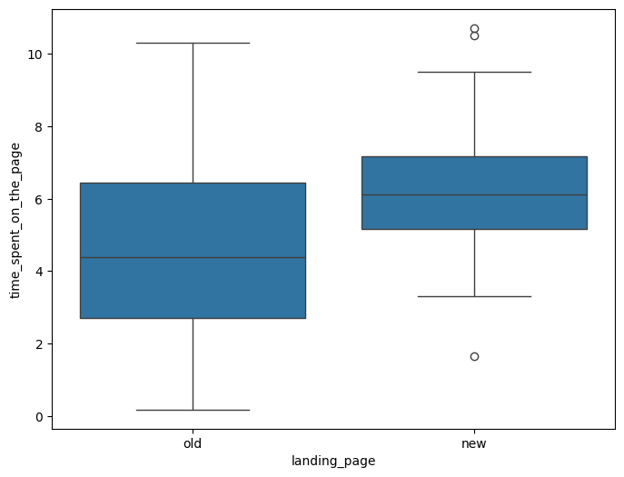

```python
# visual analysis of the time spent on the new page and the time spent on the old page
plt.figure(figsize=(8,6))
sns.boxplot(x = 'landing_page', y = 'time_spent_on_the_page', data = df)
plt.show()
```

### Step 1: Define the null and alternate hypotheses

Let:

- Let $\mu_{\text{new}}$ be the true mean time spent on the new landing page

and

- $\mu_{\text{old}}$ be the true mean time spent on the old landing page.

$H_0$: Users spend the same amount of time on the new landing page as on the existing landing page.

$H_0$: $\mu_{\text{new}} = \mu_{\text{old}}$

$H_a$: Users spend more time on the new landing page than on the existing landing page.

$H_a$: $\mu_{\text{new}} > \mu_{\text{old}}$

### Step 2: Select Appropriate test

Based on the problem:

1. We are comparing the *means* of a numerical variable (`time_spent_on_the_page`).
2. We have *two independent groups* (users who saw the 'new' page and users who saw the 'old' page).
3. The data is assumed to be numeric and likely continuous.
4. Population standard deviations are unknown.
5. One-tailed hypothesis (checking if new > old).

Given these conditions, an independent samples t-test (also known as a two-sample t-test) is the appropriate statistical test to compare the means of two independent groups.

The appropriate test is an **Independent Samples t-test (Two-Sample t-test)**.

### Step 3: Decide the significance level

Based on the problem statement, the significance level is already provided.

The significance level ($\alpha$) is given as 5%. $\alpha = 0.05$

This means that I am willing to accept a 5% chance of incorrectly rejecting the null hypothesis when it is true.

### Step 4: Collect and prepare data

```python
# Separate the time spent data for the new and old landing pages
time_spent_new = df[df['landing_page'] == 'new']['time_spent_on_the_page']
time_spent_old = df[df['landing_page'] == 'old']['time_spent_on_the_page']

# print the std
print('The sample standard deviation of the time spent on the new page is:', round(time_spent_new.std(),2))
print('The sample standard deviation of the time spent on the old page is:', round(time_spent_old.std(),2))
```

```
The sample standard deviation of the time spent on the new page is: 1.82
The sample standard deviation of the time spent on the old page is: 2.58
```

The sample standard deviations of the new and old landing pages are different, suggesting that I cannot assume equal population variances when performing the t-test. I will use Welch's t-test (independent samples t-test without equal variance assumption).

### Step 5: Calculate the p-value

```python
#import the required functions
from scipy.stats import ttest_ind

#import the required functions
from scipy.stats import ttest_ind

# calculate the p-value
t_statistic, p_value = ttest_ind(time_spent_new, time_spent_old, equal_var=False, alternative='greater')
print(f"The p-value is: {p_value:.4f}")
```

```
The p-value is: 0.0001
```

### Step 6: Compare the p-value with $\alpha$

```python
# Significance level
α = 0.05
alpha = 0.05

# p-value
# Significance level
α = 0.05
alpha = 0.05

# p-value
p_value = 0.0001

print(f"The p-value is: {p_value:.4f}")
print(f"The significance level α is: {alpha}")

# Compare p-value and alpha
if p_value < alpha:
  print("Since the p-value (", p_value, ") is less than the significance level (", alpha, "), we reject the null hypothesis.")
else:
  print("Since the p-value (", p_value, ") is greater than the significance level (", alpha, "), we fail to reject the null hypothesis.")
```

```
The p-value is: 0.0001
The significance level α is: 0.05
Since the p-value ( 0.0001 ) is less than the significance level ( 0.05 ), we reject the null hypothesis.
```

### Step 7: Draw inference

Based on the comparison: p-value (0.0001) < alpha (0.05) Decision: Reject the null hypothesis ($H_0$)

Interpretation: We reject the null hypothesis that the mean time spent on the new landing page is equal to the mean time spent on the old landing page. There is sufficient statistical evidence, at the 5% significance level, to conclude that the mean time users spend on the new landing page is significantly greater than the mean time users spend on the existing landing page.

```python
print("Inference:")
print("Since the p-value (0.0001) is less than the significance level (0.05), we reject the null hypothesis.")
print("This means there is statistically significant evidence to conclude that users spend more time on the new landing page compared to the existing landing page.")
```

```
Inference:
Since the p-value (0.0001) is less than the significance level (0.05), we reject the null hypothesis.
This means there is statistically significant evidence to conclude that users spend more time on the new landing page compared to the existing landing page.
```

**A similar approach can be followed to answer the other questions.**